# simple logistic regression on customer churn with credit score

Sebastian Ross

2026-09-12

# 1 Introduction

Customer churn is incredibly important for banks to understand, as it helps them know what they can do to retain customers. This dataset contains 10,000 customers of ABC Bank with 11 predictor variables and a response variable of churn, which indicates whether the customer left the bank or not. This dataset can be found on Kaggle at https://www.kaggle.com/datasets/gauravtopre/bank-customer-churn-dataset/data.

`customer_id`: the ID number for a customer

`credit_score`: the credit score of the person

`country`: the country the person is from

`gender`: the gender of the customer

`age`: the age of the customer

`tenure`: how long the customer has been banking, in years

`balance`: the balance of the account

`products_number`: the number of products this customer has

`credit_card`: whether the customer has a credit card

`active_member`: whether this customer is an active customer or not

`estimated_salary`: the estimated salary of the customer

`churn`: the target variable, equal to 1 if the client has left the bank during some period, or 0 if he/she has not

# 2 Exploratory Data Analysis

This section will look at the distribution of `credit_score` and see if anything needs to be done to it — specifically, whether there is any skew to the data and whether a transformation is needed. This section will also check whether there is a large disparity in the classes of the response variable `churn`.

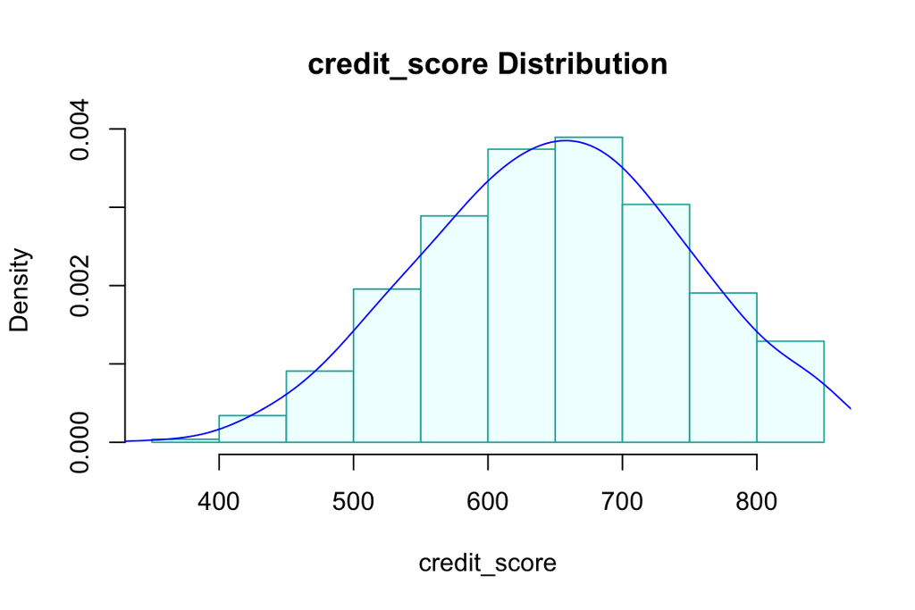

# 3 Model building

This uses 0 as the default reference value for the response variable (did not churn), so this model is predicting the probability of 1 (churn) for a customer. The model is fitted as below.

The summary stats of regression coefficients

|  | Estimate | Std. Error | z value | Pr(>\|z\|) | 2.5 % | 97.5 % |
| --- | --- | --- | --- | --- | --- | --- |
| (Intercept) | -0.9121770 | 0.1679317 | -5.431833 | 0.0000001 | -1.2419735 | -0.5836261 |
| credit_score | -0.0006956 | 0.0002568 | -2.708340 | 0.0067621 | -0.0011991 | -0.0001923 |

he coefficients show that `credit_score` has a negative association with churn, with β = −0.0006956 and a p-value of 0.0067621. This finding is supported by the 95% confidence interval [−0.0011991, −0.0001923]; this range does not include 0, confirming the estimate is meaningfully different from zero. Below we will look at the odds ratio, which is often how these coefficients are interpreted.

Summary Stats with Odds Ratios

|  | Estimate | Std. Error | z value | Pr(>\|z\|) | odds.ratio |
| --- | --- | --- | --- | --- | --- |
| (Intercept) | -0.9121770 | 0.1679317 | -5.431833 | 0.0000001 | 0.4016489 |
| credit_score | -0.0006956 | 0.0002568 | -2.708340 | 0.0067621 | 0.9993047 |

The odds ratio for `credit_score` is 0.9993047, indicating that for a one-unit increase in credit score, the odds of churn decrease by about 0.06953% per one-point increase in credit score, and by about 3.42% per 50-point increase in credit score for reference.

Below we will see several goodness-of-fit measures.

| Deviance.residual | Null.Deviance.Residual | AIC |
| --- | --- | --- |
| 10102.45 | 10109.78 | 10106.45 |

We do not need to rely heavily on these, as there is no other model on the same scale to compare them to, meaning there is no strong need for a goodness-of-fit comparison.

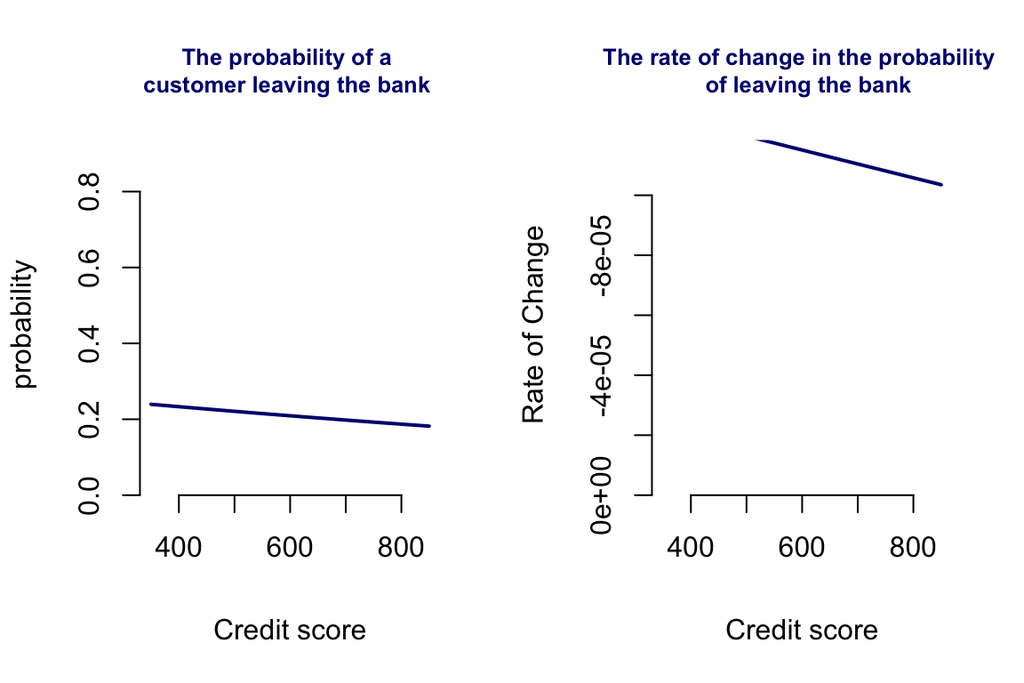

These plots tell the same story: there is a negative trend, in that as credit score increases, the likelihood of leaving the bank decreases slightly. On the left graph we would ideally like to see a strong S-shaped curve, but the nearly straight line is consistent with credit score having only a small effect on customer churn. The right graph shows that the rate of change is negative and becomes slightly less negative as credit score increases, but it remains very small in magnitude throughout. This again agrees with what we saw earlier: there is a small but present association.

# 4 Conclusion and Discussion

This analysis examined the association between credit score and customer churn. It shows a negative association: each one-unit increase in credit score is associated with a change in the log-odds of churn of approximately −0.0006956 (equivalently, a 0.0695% decrease in the odds of churn per one-point increase). This shows the association, but customer churn is a multifaceted event, so looking at credit score alone is not a good representation of why someone would leave any given bank. Through the entire range of credit scores there is a total change of roughly 5% across the entire range.